# Plotting API Results: sf, tmap, and maptiles

The quickest way to get a plot of your results is by using [`sf`](https://cran.r-project.org/package=sf) and its in-built plotting functionality. There are many packages within `R` that can be used to generate visualizations of geographic data, including [`ggplot2`](https://cran.r-project.org/package=ggplot2) and [`tmap`](https://cran.r-project.org/package=tmap). The package [`maptiles`](https://cran.r-project.org/package=maptiles) lets you add basemaps to your plots, giving your data real world context.

## Simple Features Data Frame

The OS Data Hub APIs return GeoJSON, which can be used to make a simple features data frame. This type of data frame works in a very similar way to a regular `data.frame` in `R`, with the addition of a list-like column of geometry and attributes for geospatial data. The `R` package `sf` can be used to create these objects. For more information on `sf` see the [technical documentation](https://r-spatial.github.io/sf/).

`sf` allows you to quickly visualize the data returned by your API query, using the coordinate reference system of the data to accurately plot the spatial relationships. Plotting this way can be useful to quickly check your API query results are looking like you were expecting, as well as giving you options to produce highly polished plots.

This example requests water features along a section of the Glastonbury Canal in Somerset from the ‘wtr-fts-water-1’ collection via the NGD Features API and then makes a simple plot to show what was returned.

```r
library(osdatahub)
library(sf)
```

```r
# Choose data
collection <- 'wtr-fts-water-1'

# Define query extent
W <- 342730
S <- 137700
E <- 347700
N <- 141642

crs <- 'EPSG:27700'
extent <- extent_from_bbox(c(W, S, E, N), crs = crs)

# Query API
results <- query_ngd(extent,
                     collection = collection,
                     crs = crs,
                     max_results = 100000)
```

These results are in GeoJSON format. The `sf` package can convert this format into a `data.frame` with the appropriate geometry information. Alternatively, the `osdatahub` package for `R` provides the option to return the query results as a `data.frame` object. Specify the `returnType` argument as ‘sf’ in `query_ngd()`.

```r
results_df <- st_read(results, crs = st_crs(crs), quiet = TRUE)
```

```
#> Warning: st_crs<- : replacing crs does not reproject data; use st_transform for
#> that
```

We can ignore the warning about setting the CRS in this case because we specified the API should return the features in EPSG:27700.

Now it is as simple as calling `plot()` on the data frame, including some optional styling parameters, to visualize the results. The in-built plotting commands of `sf` are detailed in this [vignette](https://r-spatial.github.io/sf/articles/sf5.html).

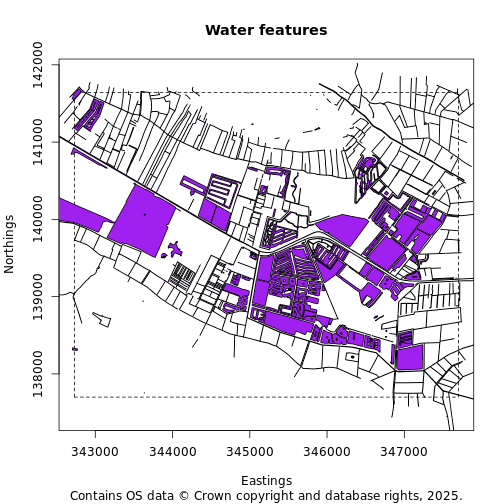

```r
# Plot the query extent
plot(st_geometry(extent$polygon),
     lty = 'dashed',
     main = 'Water features',
     axes = TRUE,
     xlab = 'Eastings',
     ylab = 'Northings')

# Plot the query results
plot(st_geometry(results_df),
     col = 'purple',
     add = TRUE)

mtext('Contains OS data © Crown copyright and database rights, 2025.', side = 1, line = 4)
```

This plot shows us the features returned form the API and plots them correctly in geogrpahic space. Once we’ve checked the results look sensible, it would be nice to see how the feaures relate to the rest of the geography of the area. To do this we might want to add a basemap, which we can do using maptiles and tmap.

## maptiles and tmap

[`maptiles`](https://github.com/riatelab/maptiles) downloads and composes images from web map tile services. You can use the OS Maps API with maptiles to get a variety of different basemaps. Find out more about the OS Maps API [here](https://osdatahub.os.uk/docs/wmts/overview). [`tmap`](https://r-tmap.github.io/tmap/) is one of the more sophisticated mapping and visualisation packages in `R` that is designed to work with `sf` objects and can display basemaps.

This first example demonstrates how to create a plot similar to the basic `sf` plot using `tmap`.

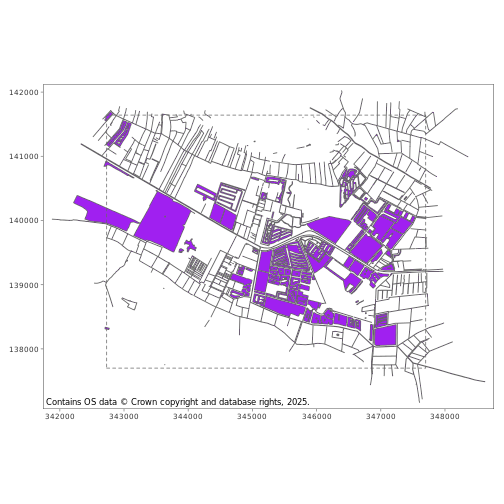

```r
library(maptiles)
library(tmap)

# Make the same plot as above, but using tmap
query_plot <- tm_shape(results_df) +
  tm_fill(col = 'purple') +
  tm_borders() +
  tm_shape(extent$polygon) +
  tm_borders(lty = 'dashed') +
  tm_grid(labels.format = list(big.mark = ""),
                lines = FALSE) +
  tm_credits('Contains OS data © Crown copyright and database rights, 2025.',
             position = c("LEFT", "BOTTOM"))

query_plot
```

To add a basemap we will retrieve the OS Maps tiles using a custom source in `maptiles`.

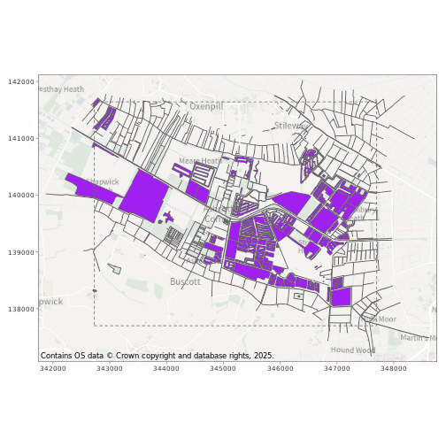

```r
# Define the tile server parameters
osmaps <- list(src = 'OS Maps',
               q = 'https://api.os.uk/maps/raster/v1/zxy/Light_3857/{z}/{x}/{y}.png?key={apikey}',
               sub = '',
               cit = 'Contains OS data © Crown copyright and database rights, 2025.')

# Download tiles and compose basemap raster
tile_maps <- get_tiles(x = extent$polygon,
                       provider = osmaps,
                       crop = FALSE,
                       cachedir = tempdir(),
                       apikey = get_os_key(),
                       verbose = FALSE)

# Add basemap to the tmap
final_plot <- tm_shape(tile_maps,
                       bbox = st_bbox(results_df)) +
                tm_rgb() +
                query_plot

final_plot
```

Note that `maptiles` currently only supports tiles in EPSG:3857 projection. The package attempts to re-project the basemap to match the CRS of the query features. This can cause some distortion in the basemap image. If this warping is not acceptable, `osdatahub` provides an alternative interface to query and download the tiles in either ESPG:27700 or EPSG:3857. However, it requires more advanced processing and some additional packages, such as `terra`.

```r
# Download tiles
res <- query_maps(extent_from_bbox(st_bbox(results_df),
                                   crs = 27700),
                  layer = 'Light_27700',
                  output_dir = tempdir())
```

```
#> Light_27700_6_161_345.png already exists. Set `overwrite` to TRUE.
#> Light_27700_6_162_345.png already exists. Set `overwrite` to TRUE.
#> Light_27700_6_163_345.png already exists. Set `overwrite` to TRUE.
#> Light_27700_6_161_344.png already exists. Set `overwrite` to TRUE.
#> Light_27700_6_162_344.png already exists. Set `overwrite` to TRUE.
#> Light_27700_6_163_344.png already exists. Set `overwrite` to TRUE.
```

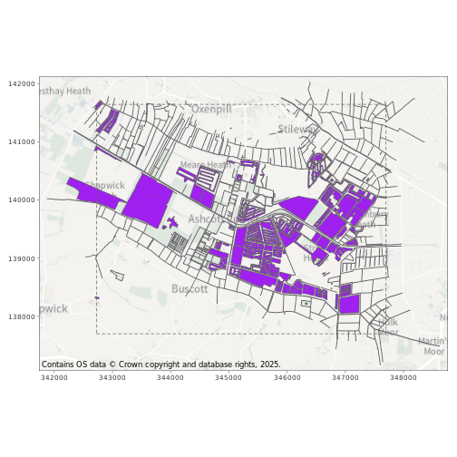

```r
# Convert tiles into georeferenced rasters
png2rast <- function(path, bbox, crs){
  img <- png::readPNG(path) * 255
  img <- terra::rast(img)
  terra::RGB(img) <- c(1,2,3)
  terra::ext(img) <- bbox[c(1,3,2,4)]
  terra::crs(img) <- crs

  return(img)
}

imgList <- lapply(res, function(t){ png2rast(t$file_path, t$bbox, t$crs) })

# Combine tiles into basemap
basemap <- do.call(terra::mosaic, imgList)

# Add basemap to the tmap
base_plot <- tm_shape(basemap,
                      bbox = results_df) +
                tm_rgb() +
                query_plot

base_plot
```